# Human Activity Recognition ML Project

Thierry Daubos

August 20, 2015

# 1. Synopsis

Our goal in this project is to design a Machine Learning algorithm based on the dataset “Weight Lifting Exercises”, provided by the research group on [Qualitative Activity Recognition of Weight Lifting Exercises](http://groupware.les.inf.puc-rio.br/har#weight_lifting_exercises) and described in the article:  
Velloso, E.; Bulling, A.; Gellersen, H.; Ugulino, W.; Fuks, H.  
Qualitative Activity Recognition of Weight Lifting Exercises.  
Proceedings of 4th International Conference in Cooperation with SIGCHI (Augmented Human ’13).  
Stuttgart, Germany: ACM SIGCHI, 2013.

The idea is to a use collection of sensors data recorded from the Arm, Forearm, Belt and Dumbbell in order to predict “how well” Unilateral Dumbbell Biceps Curls are being performed by the wearer.

# 2. Loading the pml dataset and preprocessing

We load the training and testing datasets from the appropriate directory. There aproximately 41% of NA values in the training data set. These NA values are due to “metavariables” that were introduction posterior to measurements collection by itself.

```
## [1] 0.4100856
```

## Filtering the original dataset variables

We define the set of variables below that are unrelated to the outcome we want to predict.

```r
### Removing variables unrelated to actual measurements
unused_variables <- c("cvtd_timestamp",
                      "new_window",
                      "num_window",
                      "raw_timestamp_part_1",
                      "raw_timestamp_part_2",
                      "user_name",
                      "X" )
```

Those variables are linked to the experimental settings (participant names, time stamps, rows indexing, ect.) and would not be found in a different recording session. There are irrelevant as far as our “classe”" outcome prediction is concerned and filtered out from both the train and test sets.

In Fig 1. plot in the Appendix, which display the histograme of the number of NA values present for each variables in the training set, is appears that there are two types of variables: * Variables with no NAs that come from the sensors themselves * variables with over 97% of NA values The later are clearly quantities infered from the original sensor data (max, min, average, sd) over some time window (as explained in the authors article [Qualitative Activity Recognition of Weight Lifting Exercises](http://groupware.les.inf.puc-rio.br/public/papers/2013.Velloso.QAR-WLE.pdf) )

```
## [1] 86
```

Similarly, we remove from the test set variables that we listed as unrelated and variables containing only NA values.

```
## [1] 53
```

Finally, we keep only predictors that are common to both the training and test sets.  
That corresponds to 52 predictors on which we are going to use to build our predictive model.

```
## [1] 52
```

# 3. Redefinition of the train and test data sets

From the cleanned up list of variables, we define the two new datasets:

```r
### Redefine the train and data sets
data_train <- pml_training[,c("classe", names_final)]
data_test  <- pml_testing [,            names_final ]
```

Our new training dataset is further split into training and test datasets with a ration of roughly 70% of the data in the training set and 30% in the test set.

```r
library(caret)
inTrain  <- createDataPartition(y=data_train$classe, p=0.7, list=FALSE)
training <- data_train[ inTrain,]
testing  <- data_train[-inTrain,]
dim(training); dim(testing)
```

```
## [1] 13737    53
```

```
## [1] 5885   53
```

# 4. Design of the machine learning algorithm

For the machine learning algorithm, we use the random forest approach and the randomForest package (which is much faster than the train function with method=“rf” from the caret package). Random forest algorithms are equally well suited for regression or classification tasks as ours.

The main tuning metaparameter of the algorithm are:  
* mtry : the number of predictors sampled for spliting at each node  
* ntree : number of trees grown by the forest

The necessary Number of trees to grow can be estimated using the plot function of the package which displays the Mean Squared Error as a function of number of trees for each classe. From Fig 3. in the Appendix, we evaluate the sufficient number of trees around 150.

Here’s the final model with it’s Confusion Matrix on the training dataset:

```r
# Random Forest model using randomForest
library(randomForest)
modFit  <- randomForest(classe ~ .,
                        data  = training,
                        test  = testing,
                        mtry  = 8,
                        ntree = 150,
                        importance = TRUE,
                        test  = TRUE
                        )
modFit$confusion
```

```
##      A    B    C    D    E class.error
## A 3899    6    1    0    0 0.001792115
## B   11 2640    7    0    0 0.006772009
## C    0   15 2380    1    0 0.006677796
## D    0    0   24 2226    2 0.011545293
## E    0    0    2    6 2517 0.003168317
```

Fig. 4 in the Appendix shows the variable importance plot for the 10 most important variables in terms of Mean Decrease in Accuracy and Mean Decrease Gini brought by each variable.

# 4. Out of Sample Error

When applying our predictive model to the test set, we obtain the following confusion matrix:

```
##
## pred    A    B    C    D    E
##    A 1672    3    0    0    0
##    B    2 1134    3    0    0
##    C    0    2 1023    9    2
##    D    0    0    0  955    3
##    E    0    0    0    0 1077
```

From which we calculate the Out of Sample Accuracy for the test set:

```
## [1] 0.9959218
```

And the corresponding Out of Sample error:

[output not shown]

# 5. Appendix

## Fig 1. : Histograme of the number of NA values in training set

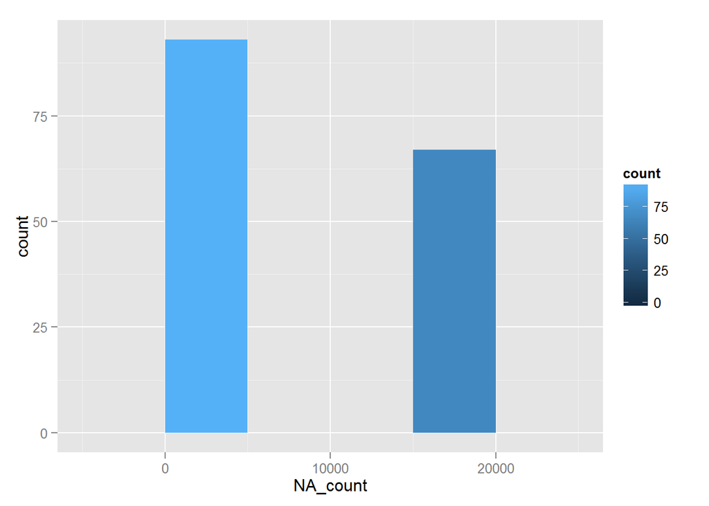

## Fig 2. : Tuning of randomForest algorithm for optimal mtry parameter

```
## mtry = 1  OOB error = 1.97%
## Searching left ...
## Searching right ...
## mtry = 2     OOB error = 1.06%
## 0.4612546 0.05
## mtry = 4     OOB error = 0.85%
## 0.1986301 0.05
## mtry = 8     OOB error = 0.71%
## 0.1623932 0.05
## mtry = 16    OOB error = 0.72%
## -0.01020408 0.05
```

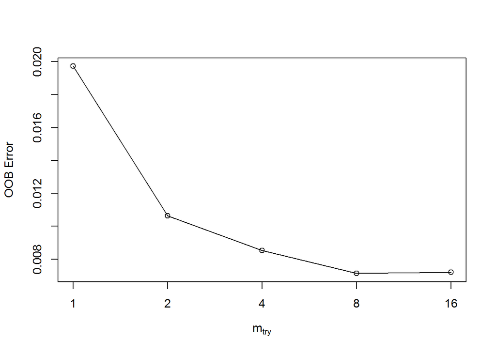

```
##        mtry    OOBError
## 1.OOB     1 0.019727743
## 2.OOB     2 0.010628230
## 4.OOB     4 0.008517143
## 8.OOB     8 0.007134018
## 16.OOB   16 0.007206814
```

## Fig 3. : Tuning the number of trees to grow by randomForest

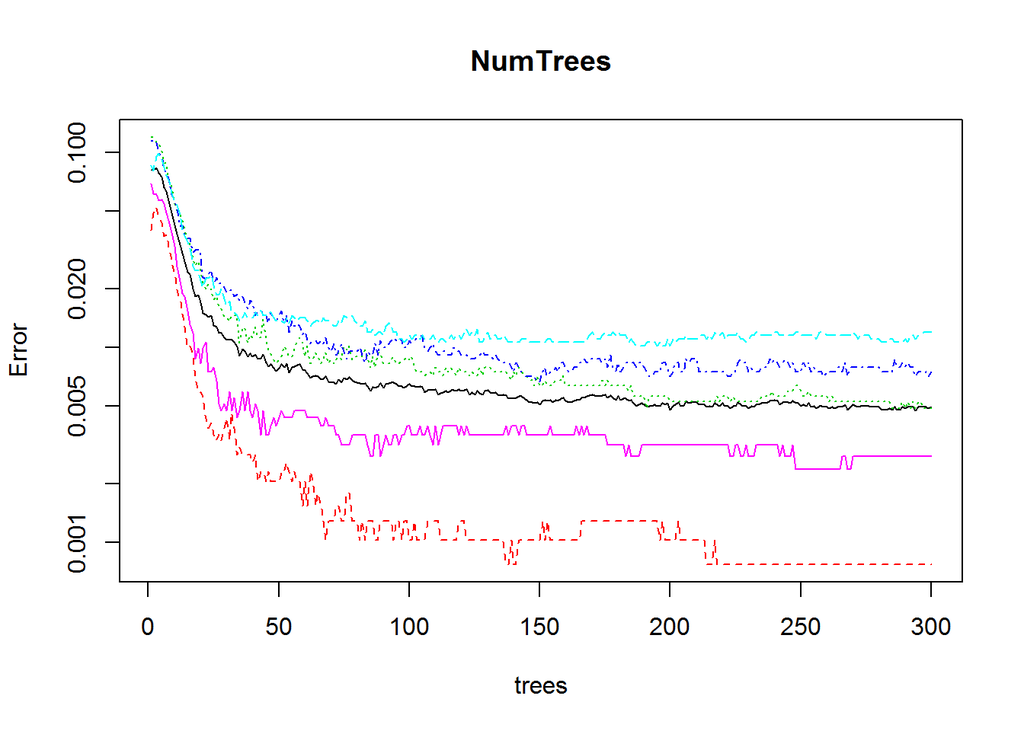

## Fig 4. : Vaiable importance plot

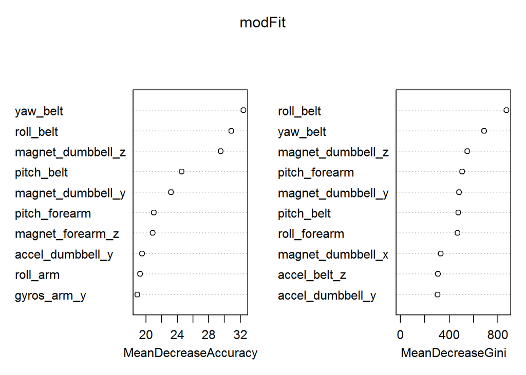